# Introduction to Machine Learning in R (K Nearest Neighbours Algorithm)

Samuel Kellerhals

28/08/2018

## What is Machine Learning?

Today machine learning is everywhere. From the content delivered to you on your Facebook newsfeed to the spam emails being filtered out of your emails, we live in an increasingly data driven society.

A widely quoted, more formal definition of machine learning is:

> “A computer program is said to learn from experience E with respect to some class of tasks T and performance measure P if its performance at tasks in T, as measured by P, improves with experience E.”

In simple terms, Machine Learning is the science of developing and making use of specialised statistical learning algorithms that produce a predictive model based on information gathered from input data. This is closely related to computational statistics and therefore is far from any wizardry, rather it is based on established methodologies that also come with their flaws. It is therefore important to understand the implications of using off-the-shelf machine learning algorithms when building predictive models to aid knowledge discovery and decision making.

### The k-nearest neighbour algorithm (k-nn)

In this tutorial you will be introduced to a simple and well established supervised classification algorithm, and will implement it in R.

| Main machine learning domains | Description |
| --- | --- |
| [Unsupervised learning](https://en.wikipedia.org/wiki/Unsupervised_learning) | Inferring a function that describes the structure of “unlabeled” data (i.e. data that has not been classified or categorized). |
| [Supervised learning](https://en.wikipedia.org/wiki/Supervised_learning) | Learning a function that maps an input to an output based on example input-output pairs. |
| [Deep learning algorithms](https://en.wikipedia.org/wiki/Deep_learning) | Part of a broader family of machine learning methods based on learning data representations, as opposed to task-specific algorithms. Learning can be supervised, semi-supervised or unsupervised |
| [Reinforcement learning](https://en.wikipedia.org/wiki/Reinforcement_learning) | An area of machine learning concerned with how software agents ought to take actions in an environment so as to maximize some notion of cumulative reward. |

K-nn is an example of a supervised learning method, which means we need to first feed it data so it is able to make a classification based on that data (this is called the training phase). Upon training the algorithm on data we provided, we can test our model on an unseen dataset (where we know what class each observation belongs to), and can then see how successful our model is at predicting the existing classes. This process of first building or selecting a classifier, training it and subsequently testing it is very widespread across the machine learning field and is what you will be doing today.

### Under the hood

K-nn is a non-parametric technique that stores all available cases and classifies new cases based on a similiarty measure (distance function). Therefore when classifying an unseen dataset using a trained k-nn algorithm, it looks through the training data and finds the **k** training examples that are closest to the new example. It then assigns a class label to the new example based on a majority vote between those **k** training examples. This means if **k** is equal to 1, the class label will be assigned based on the nearest neighbour. However if K is equal to 3, the algorithm will select the three closest data points to each case and classify it based on a majority vote based on the classes that those three adjacent points hold.

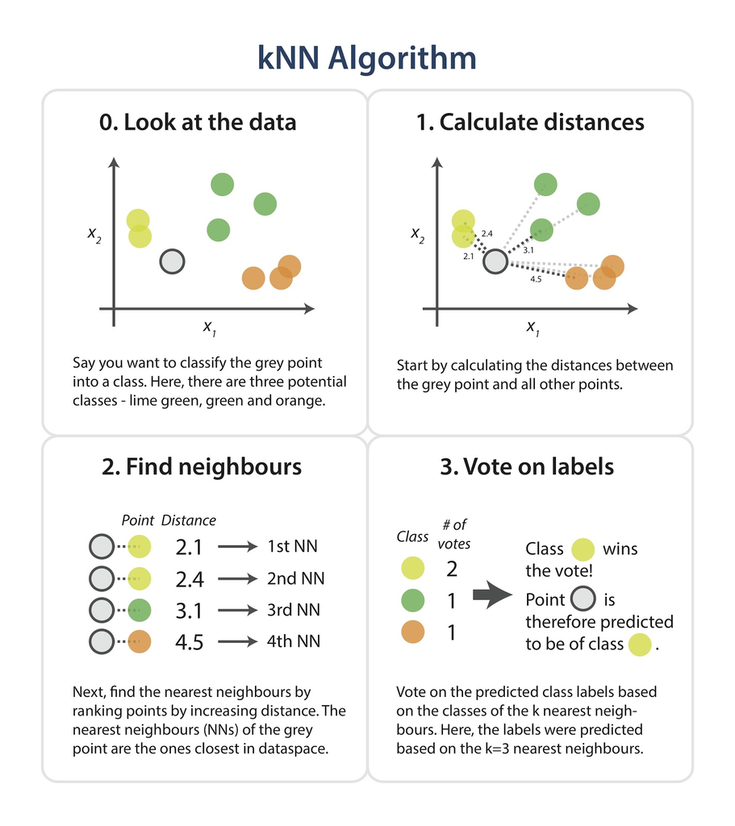

You can see that the selection of **k** is quite important, as is the selection of your training data, because this is all your predictive model will be based on. Regarding **k**, generally in binary cases it is best to pick an odd K value to avoid ties between neigbours. Slightly higher **k** values can also act to reduce noise in datasets. However it is best to experiment with different **k** values and use [cross validation techniques](https://genomicsclass.github.io/book/pages/crossvalidation.html) to find the best value for your specific case.

## Getting started

Navigate to the repository for this tutorial at https://github.com/ourcodingclub/CC-knn-algorithm, and clone the repository to your local machine. To do so, either download the repository contents or alternatively if you have installed [git](https://git-scm.com/) already, you can use the following command in your terminal or command-prompt:

```
git clone 'repository name'
```

Now that you have the neccesary files for this tutorial you can go ahead and open up RStudio. If you are new to R then feel free to check out [getting started with R](https://ourcodingclub.github.io/2016/11/13/intro-to-r.html).

Today we will use the following packages, go ahead and install them if you haven’t aready, then load them.

```r
# Example of installing a package
install.packages('ggplot2')
```

```r
# Loading required packages for this tutorial
library(ggplot2)
library(dplyr)
library(class)
library(gridExtra)
library(gmodels)
```

### Loading our data

For this tutorial we will be using the built-in Iris UCI Machine Learning dataset. In order to start learning something from our data, it is first important that we familiarise ourselves with it first.

```r
# Loading iris dataset
iris.data <- iris

# Viewing iris dataset structure and attributes
str(iris.data)
```

```
## 'data.frame':    150 obs. of  5 variables:
##  $ Sepal.Length: num  5.1 4.9 4.7 4.6 5 5.4 4.6 5 4.4 4.9 ...
##  $ Sepal.Width : num  3.5 3 3.2 3.1 3.6 3.9 3.4 3.4 2.9 3.1 ...
##  $ Petal.Length: num  1.4 1.4 1.3 1.5 1.4 1.7 1.4 1.5 1.4 1.5 ...
##  $ Petal.Width : num  0.2 0.2 0.2 0.2 0.2 0.4 0.3 0.2 0.2 0.1 ...
##  $ Species     : Factor w/ 3 levels "setosa","versicolor",..: 1 1 1 1 1 1 1 1 1 1 ...
```

From this we can see that this dataset contains 150 observations describing plant structural traits such as Sepal Length and Petal Width of the Iris genus across three different species.

### Data visualisation

We can also visualise our data to understand whether there are any apparent trends. Often exploring our data this way will yield an even better understanding of any underlying relationships we may want to explore further using Machine Learning algorithms such as the k-nn.

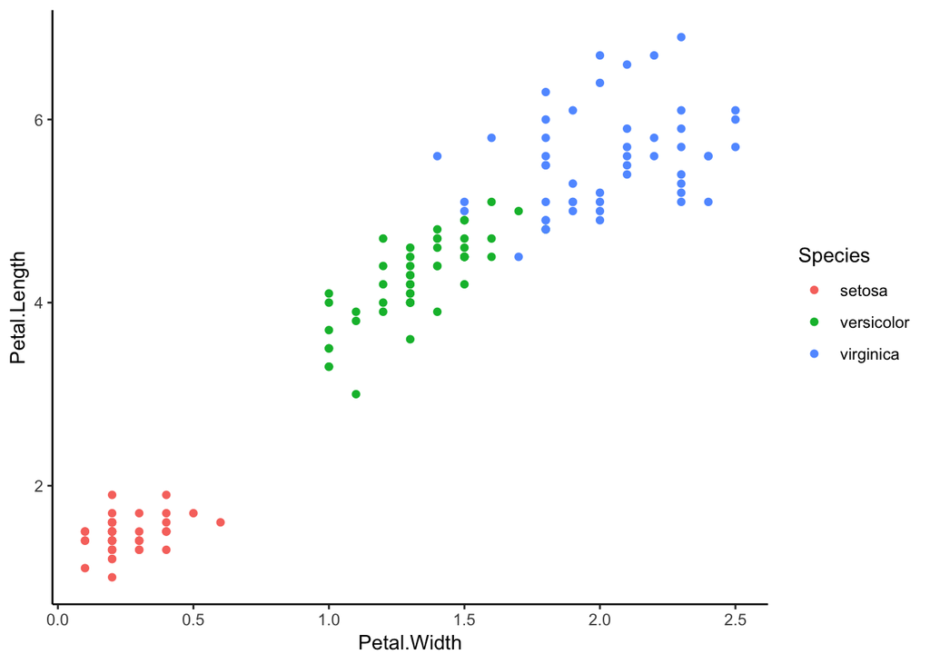

```r
# Scatter plot visualising petal width and length grouped by species
ggplot(iris.data, aes(x = Petal.Width, y = Petal.Length, color = Species)) +
  geom_point() +
  theme_classic()
```

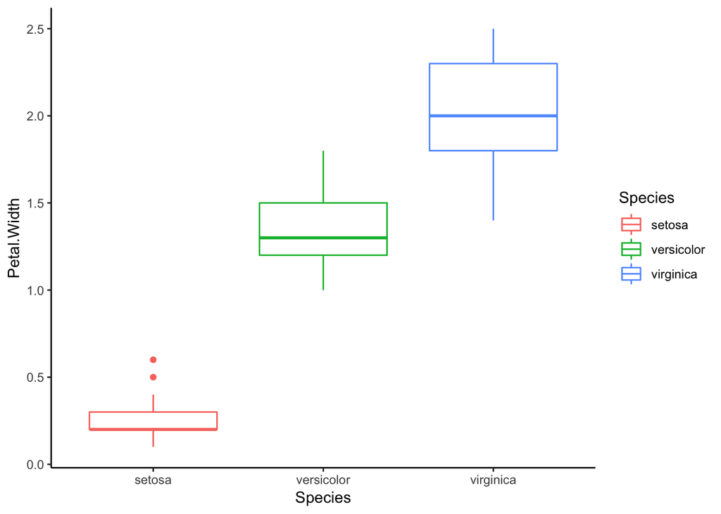

```r
# Boxplot visualising variation in petal width between species
ggplot(iris.data, aes(x = Species, y = Petal.Width, color = Species)) +
  geom_boxplot() +
  theme_classic()
```

From the above plots we see a visual correlation between plant traits. We can also see that there is some clustering within species with traits varying greatly between the three iris species. Now that we know that there is a clear difference in structural traits between species we could ask the following question:

*Could we predict what species iris plants belong to based on structural trait data alone?*

The goal of this tutorial will be to answer this question by building a predictive model and assessing its performance. To do so we will take a random sample of our data which we will use as training data, and another sample which will be used to test our model. These final predictions can then be compared to our original data so we can assess our results and see how accurate our model is.

## Building our k-nn classifier

### Data normalisation and training/test-set generation

The scales of individual variables may vary with a given dataset. For example one variable may have values ranging from 0 - 1 while the other ranges from 0 - 1000. Therefore some scaling/normalisation is often useful, espescially with the knn algorithm which is quite sensitive to different intervals across variables given that it employs a distance function when searching for ‘nearest-neighbours’.

```r
# Building a normalisation function
normalise <- function(x) {
  num <- x - min(x)
  denom <- max(x) - min(x)
  return (num/denom)
}
```

For further understanding why feature normalisation is useful see [this lecture](http://www.uta.fi/sis/tie/tl/index/Datamining4.pdf) and/or a very good answer on this topic on StackOverflow. Now we normalise all the continous data columns in the iris dataset by applying our function to the iris data.

```r
iris.norm <- as.data.frame(lapply(iris[1:4], normalise))
```

Now that our data is normalised, we are going to randomly generate our training and test samples and their respective labels/classes.

This is done using the `sample` function which generates a random sample of the specified size from the data set or elements. Also note that before calling `sample` we also call the `set.seed` function. This ensures that we always generate the same random data sample, as otherwise each time we would run this code a completely new random sequence would be generated. More information on that [here](http://www.datasciencemadesimple.com/sample-function-in-r/).

```r
# Generating seed
set.seed(1234)

# Randomly generating our training and test sampels with a respective ratio of 2/3 and 1/3
datasample <- sample(2, nrow(iris.norm), replace = TRUE, prob = c(0.67, 0.33))

# Generate training set
iris.training <- iris.norm[datasample == 1, 1:4]

# Generate test set
iris.test <- iris.norm[datasample == 2, 1:4]
```

The next step is to generate our training and test labels. Beware however, we now need to use our original (not-normalised) dataset that also includes our class labels (column 5), while in the previous step we were just interested in our continous variables (columns 1-4). If this is not clear view all datasets again before proceeding.

```r
# Generate training labels
irisTraining.labels <- iris[datasample == 1, 5]

# Generate test labels
irisTest.labels <- iris[datasample == 2, 5]
```

It’s now time to build our classifier! For this we will use the `knn` function from the `class` package. We will pass the function the following parameters:

- Our normalised training dataset
- Our normalised test dataset
- Our original training labels
- A value for K

```r
# Building our knn classifier
iris.knn <- knn(train = iris.training, test = iris.test, cl = irisTraining.labels, k = 3)
```

Next, we need to evaluate the performance of our model. To do this we want to find out if the classes our algorithm predicts based on the training data accurately predict the species classes in our original iris dataset. For this we compare the original class labels to the predictions made by our algorithm.

```r
# creating a dataframe from known (true) test labels
test.labels <- data.frame(irisTest.labels)

# combining predicted and known species classes
class.comparison <- data.frame(iris.knn, test.labels)

# giving appropriate column names
names(class.comparison) <- c("Predicted Species", "Observed Species")
```

Let’s have a look at how our model did by inspecting the `class.comparison` table to see if our predicted species align with our observed species.

```r
# inspecting our results table
class.comparison
```

[output not shown]

Finally we can also evaluate the model using a cross-tabulation table.

```r
CrossTable(x = irisTest.labels, y = iris.knn, prop.chisq = FALSE)
```

```
##
##
##    Cell Contents
## |-------------------------|
## |                       N |
## |           N / Row Total |
## |           N / Col Total |
## |         N / Table Total |
## |-------------------------|
##
##
## Total Observations in Table:  40
##
##
##                 | iris.knn
## irisTest.labels |     setosa | versicolor |  virginica |  Row Total |
## ----------------|------------|------------|------------|------------|
##          setosa |         12 |          0 |          0 |         12 |
##                 |      1.000 |      0.000 |      0.000 |      0.300 |
##                 |      1.000 |      0.000 |      0.000 |            |
##                 |      0.300 |      0.000 |      0.000 |            |
## ----------------|------------|------------|------------|------------|
##      versicolor |          0 |         12 |          0 |         12 |
##                 |      0.000 |      1.000 |      0.000 |      0.300 |
##                 |      0.000 |      0.857 |      0.000 |            |
##                 |      0.000 |      0.300 |      0.000 |            |
## ----------------|------------|------------|------------|------------|
##       virginica |          0 |          2 |         14 |         16 |
##                 |      0.000 |      0.125 |      0.875 |      0.400 |
##                 |      0.000 |      0.143 |      1.000 |            |
##                 |      0.000 |      0.050 |      0.350 |            |
## ----------------|------------|------------|------------|------------|
##    Column Total |         12 |         14 |         14 |         40 |
##                 |      0.300 |      0.350 |      0.350 |            |
## ----------------|------------|------------|------------|------------|
##
##
```

We can see that our algorithm was able to almost predict all species classes correctly, except for two cases where virginica was falsely classified by our algorithm as versicolor. However all in all this is already a good result!

### Summary and Next steps

We have now covered:

- the very basics of machine learning in R
- implementing k-nearest neighbour classification
- building our own training and test datasets
- testing and evaluating our knn algorithm

However there is still a whole world to explore. For those interested in learning more have a look at this [freely available book](https://daviddalpiaz.github.io/r4sl/index.html) on machine learning in R.

You can now also go ahead and try to implement your own knn model using your own data or an established dataset such as the one used in this tutorial.